# Developing Data Product Project

Sriram Cheruvu

August 7, 2018

## Overview

This project builds a ShinyApp using the IRIS dataset and illustrates how k based clustering works when the user dynamically selects the X and Y variables from the IRIS dataset.In addition, the user is provided with the option to select the cluster size (between 1 to 7 clusters).

The user can slice and analyse the data in a pair wise format and try different options in specifying the number of clusters.

## Project Instructions

1. Write a shiny application with associated supporting documentation. The documentation should be thought of as whatever a user will need to get started using your application.
2. Deploy the application on Rstudio’s shiny server
3. Share the application link by pasting it into the provided text box
4. Share your server.R and ui.R code on github

## Application Hosting

The Shiny application created for this project can be found at: https://sricheruvu.shinyapps.io/ShinyAppProject/

The presentation for this project can be found at: http://rpubs.com/sricheruvu/

## Application User Instructions

The following are the steps the user needs to do to run this application:

1. Identify pairwise clusters in the IRIS dataset by:
   1. Selecting X variable.
   2. Selecting Y variable.
2. Select number of clusters (between 1 to 7 clusters)

Depending on the inputs the app will cluster the observations into the number of clusters specified.

```r
summary(iris)
```

```
##   Sepal.Length    Sepal.Width     Petal.Length    Petal.Width
##  Min.   :4.300   Min.   :2.000   Min.   :1.000   Min.   :0.100
##  1st Qu.:5.100   1st Qu.:2.800   1st Qu.:1.600   1st Qu.:0.300
##  Median :5.800   Median :3.000   Median :4.350   Median :1.300
##  Mean   :5.843   Mean   :3.057   Mean   :3.758   Mean   :1.199
##  3rd Qu.:6.400   3rd Qu.:3.300   3rd Qu.:5.100   3rd Qu.:1.800
##  Max.   :7.900   Max.   :4.400   Max.   :6.900   Max.   :2.500
##        Species
##  setosa    :50
##  versicolor:50
##  virginica :50
##
##
##
```

```r
head(iris)
```

```
##   Sepal.Length Sepal.Width Petal.Length Petal.Width Species
## 1          5.1         3.5          1.4         0.2  setosa
## 2          4.9         3.0          1.4         0.2  setosa
## 3          4.7         3.2          1.3         0.2  setosa
## 4          4.6         3.1          1.5         0.2  setosa
## 5          5.0         3.6          1.4         0.2  setosa
## 6          5.4         3.9          1.7         0.4  setosa
```

```
## K-means clustering with 3 clusters of sizes 65, 20, 65
##
## Cluster means:
##       [,1]
## 1 5.072308
## 2 7.235000
## 3 6.186154
##
## Clustering vector:
##   [1] 1 1 1 1 1 1 1 1 1 1 1 1 1 1 3 3 1 1 3 1 1 1 1 1 1 1 1 1 1 1 1 1 1 1 1
##  [36] 1 1 1 1 1 1 1 1 1 1 1 1 1 1 1 2 3 2 1 3 3 3 1 3 1 1 3 3 3 1 3 1 3 3 1
##  [71] 3 3 3 3 3 3 2 3 3 3 1 1 3 3 1 3 3 3 1 1 1 3 3 1 1 3 3 3 1 3 3 3 2 3 3
## [106] 2 1 2 3 2 3 3 2 3 3 3 3 2 2 3 2 1 2 3 3 2 3 3 3 2 2 2 3 3 3 2 3 3 3 2
## [141] 3 2 3 2 3 3 3 3 3 3
##
## Within cluster sum of squares by cluster:
## [1] 7.770154 2.565500 6.817538
##  (between_SS / total_SS =  83.2 %)
##
## Available components:
##
## [1] "cluster"      "centers"      "totss"        "withinss"
## [5] "tot.withinss" "betweenss"    "size"         "iter"
## [9] "ifault"
```

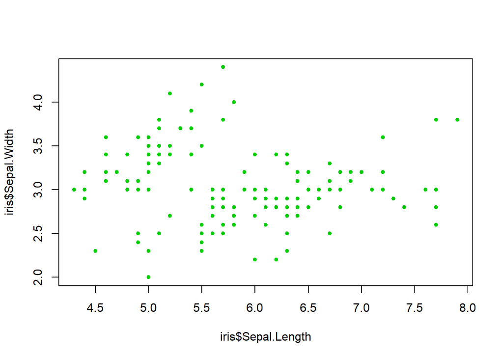

## Conclusion

We used shiny application to demonstrate how flexible the output can be based on the input parameters selected by the user. Clustering using K means have been used to cluster the data from the IRIS dataset based on the inputs selected.